# fitting_LPA_model

## Introduction

This vignette illustrates Dirichlet Process Mixture Latent Profile Analysis (DPM-LPA). It uses a fake data set (lpa_example_data) that includes data from several cognitive tasks (nback_digit, nback_picture, stroop, trail_making, wcst) and school grades in different subjects (math, reading, gym). The goal of the analysis is to form latent profiles based on the cognitive tasks then see whether these profiles are related to school grades.

## Set up

### Load the dpm.lpa R package

```r
library(dpm.lpa)
```

```
#> [1] "Updating Python packages (if necessary)."
```

```r
# To build: devtools::build_vignettes()
```

### Load data

```r
data(lpa_example_data)
```

### Fit the DPM-LPA model

This function fits the DPM-LPA model to your data.

```r
fitted_lpa = fit_dpm_lpa(x = lpa_example_data[, c('wcst', 'stroop', 'trail_making', 'nback_digit', 'nback_picture')])
```

## Assess model assumptions

### Plot histograms of residuals (normality assumption)

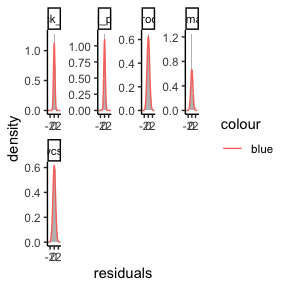

```r
plot_lpa_residuals(fitted_lpa)
```

### Look at residual correlation matrix (local independence assumption)

Standard LPA assumes that the observed variables (x) are independent conditioned on latent profile. Thus, the residuals should be uncorrelated. This function plots the residual correlation matrix. The off-diagonal elements should be close to 0. However, we can see that the correlation between nback_digit and nback_picture is extremely high, suggesting that these variables are redundant. One of them should be dropped.

```r
lpa_residual_correlations(fitted_lpa)
```

```
#>    wcst stroop trail_making nback_digit nback_picture
#> 1  1.00  -0.15         0.17       -0.13         -0.09
#> 2 -0.15   1.00         0.05       -0.16         -0.19
#> 3  0.17   0.05         1.00       -0.02          0.01
#> 4 -0.13  -0.16        -0.02        1.00          0.92
#> 5 -0.09  -0.19         0.01        0.92          1.00
```

## Fit the model again with revised data

### Revise the data set

We will log-transform trail_making to fix its skewed residuals, and drop nback_picture because its residuals are so highly correlated with those of nback_digit.

```r
x_v2 = lpa_example_data[, c('wcst', 'stroop', 'trail_making', 'nback_digit')] # drop nback_picture
x_v2$trail_making = log(x_v2$trail_making) # log-transform trail_making
x_v2 = as.data.frame(scale(x_v2)) # scale, i.e. z-score
```

### Re-fit the model

```r
fitted_lpa_v2 = fit_dpm_lpa(x = x_v2)
```

### Check residual normality again

All of the residuals look nice and normally distributed. It looks like the log-transformation of trail_making worked.

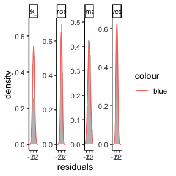

```r
plot_lpa_residuals(fitted_lpa_v2)
```

```r
lpa_residual_correlations(fitted_lpa_v2)
```

```
#>    wcst stroop trail_making nback_digit
#> 1  1.00  -0.28         0.01       -0.21
#> 2 -0.28   1.00         0.12       -0.02
#> 3  0.01   0.12         1.00       -0.06
#> 4 -0.21  -0.02        -0.06        1.00
```

## Look at the fitted model

### Print summary of profile fit

This function gives a basic summary of the fitted LPA model, including the number of observations (participants), the proportional reduction in entropy (a measure of how “certain” the model is in assigning participants to profiles), the number of profiles, the number of people in each profile, estimates of profile means (mu) etc.

```r
print_lpa_summary(fitted_lpa_v2)
```

```
#> n = 200
#>
#> proportional entropy reduction: 0.89
#> (= 1 - entropy of z/max entropy of z)
#>
#> number of non-empty profiles: 3
#>
#> pi (profile probabilties):
#>   profile 1  profile 2  profile 3
#>        0.55       0.34       0.11
#>
#> number in each profile:
#>   profile 1  profile 2  profile 3
#>         110         68         22
#>
#> mu: (means)
#>               profile 1  profile 2  profile 3
#> wcst               0.49      -1.00       0.49
#> stroop             0.59      -0.99       0.08
#> trail_making      -0.10      -0.13       0.67
#> nback_digit       -0.12      -0.39       1.36
#>
#> xi: (precisions, i.e. inverse variances)
#>   wcst  stroop  trail_making  nback_digit
#>   1.86    1.93          1.06         1.43
#>
#> proportion of the sample contained in the K biggest profiles
#>   K = 1  K = 2  K = 3
#>    0.55   0.89    1.0
```

### Plot estimated profile means (mu)

This plots the estimated means of each profile on each latent variable. By default, the plot is broken into facets (subplots) based on latent profile, with variable on the x-axis, and the posterior distribution expected values of each profile mean are plotted as bars. However other varieties of plot are available: see the function’s documentation for details.

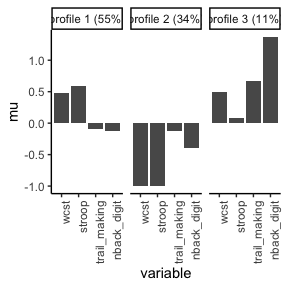

```r
plot_profile_means(fitted_lpa_v2)
```

### Plot estimated profile base rates (probabilities, pi) This simply plots the estimated base rates (probabilities) of the latent profiles using bars.

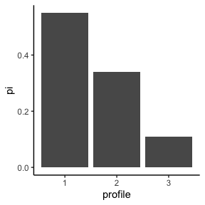

```r
plot_profile_probs(fitted_lpa_v2)
```

## Extract estimated latent profiles

### Extract “hard” estimates of latent profiles

This function extracts a data frame of “hard” estimates of each participant’s latent profile, i.e. the most probable latent profile for each participant. This data can then be used for other analyses, exported (using write.csv for example) etc.

```r
profiles = extract_profiles(fitted_lpa_v2)
head(profiles)
```

```
#>      profile
#> ID_1       1
#> ID_2       1
#> ID_3       1
#> ID_4       3
#> ID_5       1
#> ID_6       1
```

### Extract “soft” estimates of latent profiles

By specifying ‘profile_probs = TRUE’, the function will instead extract a data frame of “soft” latent profiles estimates, i.e. the probability that each person is in each latent profile.

```r
soft_profiles = extract_profiles(fitted_lpa_v2, profile_probs = TRUE)
head(soft_profiles)
```

```
#>      P(profile 1) P(profile 2) P(profile 3)
#> ID_1    0.9861563 8.579349e-03  0.005243390
#> ID_2    0.9982505 1.501239e-05  0.001732197
#> ID_3    0.9574621 2.036478e-02  0.022139496
#> ID_4    0.4191686 3.260224e-04  0.580496427
#> ID_5    0.9865711 1.079460e-02  0.002613786
#> ID_6    0.9752380 1.364390e-03  0.023383462
```